# PEC 1 - Análisis de datos Ómicos

Candela Sánchez Alvarez

7 de April, 2026

# Ejercicio 1. Exploración multivariante de un datast de metabolómica.

## 1. Introducción y objetivos.

La metabolómica es el estudio de metabolitos (moléculas pequeñas) presentes en los productos finales de los procesos celulares (National Cancer Institute s.f.). Además, no solo permite la identificación de biomarcadores de enfermedades en forma de metabolitos endógenos (metabolitos derivados de los genes) y exógenos (metabolitos derivados del ambiente), sino que también da información importante sobre la causa de las enfermedades (Wishart 2016).

Sin embargo, según Worley and Powers (2013) la elevada información sobre estudios metabólicos plantean un desafío para obtener conclusiones biológicamente relevantes a partir de cualquier conjunto de datos metabólicos. Por ello, se necesitan métodos especializados de análisis de datos, como los que se han aplicado en este estudio. En este estudio, se ha realizado un filtración de los datos basada en la regla del 80% para evitar sesgos que degraden la señal biológica. Además, se han normalizado y autoescalado los datos para estabilizar la varianza y que todos los metabolitos tengan la misma importancia estadística para su posterior análisis (Berg et al. 2006). Finalmente, se ha utilizado el análisis de componentes principales (PCA) que permite visualizar agrupamientos y detectar outliers. No obstante, se ha añadido el algoritmo t-SNE (t-Distributed Stochastic Neighbor Embedding) para observar si los resultados son similares y si hay información complementaria que no se puede ver con el PCA (Berg et al. 2006; Van der Maaten and Hinton 2008).

El presente estudio tiene como objetivo realizar un análisis exploratorio mediante técnicas de preprocesamiento, visualización multivariante lineal y no lineal para identificar patrones biológicos y biomarcadores que permitan diferenciar entre pacientes sanos y enfermos. Para ello, se utiliza el contenedor SummarizedExperiment que permite gestionar la matriz de datos, los metadatos de las muestras y las caracteristicas de las variables.

## 2. Métodos.

### 2.1.Contrucción del contenerdor y selección de muestras.

En este estudio se ha utilizado el contenedor de Bioconductor **SummarizedExperiment**, con el objetivo de coordinar datos de ensayo con metadatos de muestras y variables. El contenedor esta formado por tres fuentes de datos que son: la matriz de datos (assay.csv), los metadatos de las muestras (sample_metadata.csv) y los metadatos de variables (feature_metadata.csv) (Huber et al. 2015).

Se ha realizado una personalización de los datos mediante un muestreo aleatorio balanceado por grupo, para obtener un subconjunto final con 25 muestras de cada uno de los dos grupos de estudio (“Case” y “Control”). Para ello, se ha utlizado una semilla 2603. En el proceso de selección, se ha indentificado las muestras de cada grupo y, después, se han seleccionado 25 muestras al azar de cada subgrupo. Las muestras que se han seleccionado para el análisis son:

```
##  [1] "S052" "S035" "S055" "S032" "S045" "S059" "S057" "S031" "S056" "S039"
## [11] "S043" "S038" "S051" "S037" "S047" "S033" "S034" "S044" "S041" "S040"
## [21] "S048" "S054" "S046" "S050" "S036" "S014" "S007" "S024" "S001" "S009"
## [31] "S003" "S025" "S015" "S029" "S012" "S016" "S005" "S018" "S006" "S011"
## [41] "S013" "S021" "S002" "S028" "S017" "S030" "S004" "S008" "S020" "S026"
```

### 2.2. Preparación de los datos.

Una vez seleccionados los datos que se van a utilizar para el análisis, se procedió a la limpieza de la matriz de datos. En metabólica, normalmente se encuentran valores faltantes, por lo que es muy importante seguir los siguientes pasos para eliminar el ruido técnico y corregir la heterocedasticidad (Wei et al. 2018; Di Guida et al. 2016):

- **Filtar las variables mediante la regla del 80%**, en la cuál, se eliminaran aquellos metabolitos con más de un 20% de valores faltantes. Según Wei et al. (2018), no eliminar las varaibles que tienen un nivel de ausencia mayor al 20% puede provocar un sesgo artificial que degrada la señal biológica y la fiabilidad de los resultados estadísticos.
- **Imputación mediante el algoritmo K-NN (*k=5*)**: para los metabolitos restantes (aquellos con menos del 20% de valores faltantes), se aplica la imputación basada en los *k* vecinos más cercanos. El uso de este algoritmo es muy efectivo para destacar la capacidad para preservar las relaciones entre metabolitos.
- **Normalización y autoescalado**: se aplica en los datos una transformación logarítmica $log_2(x+1)$ para estabilizar la varianza de manera que las variables se aproximen a una distribución normal. Además, se ha realizado un autoscaling para que todos los metabolitos tengan la misma importancia estadistica en el análisis (Berg et al. 2006).

### 2.3. Análisis mediante PCA

Para el análisis de datos se aplica el análisis de componentes principales (PCA) sobre la matriz de datos que ha sido procesada anteriormente, es decir, transformada, imputada y escalada. Según Berg et al. (2006) el PCA es una técnica lineal que intenta explicar la mayor variación posible con el menor número de componentes. Además, es muy importante para identificar outliers y los metabolitos más importante para el problema biológico mediante el análisis de las cargas.

### 2.4. Comparación con otros métodos.

Finalmente, se ha realizado un método diferente al PCA para poder comparar los resultados y ver si se observan cosas diferentes o nuevas que el PCA ha podido omitir. En este caso, hemos seleccionado el algoritmo t-Distributed Stochastic Neighbor Embedding (t-SNE), que es una técnica no lineal capaz de capturar las estructuras no lineales. Según Awan (2024), a diferencia del PCA, preserva las relaciones entre los puntos de datos en una espacio de menor dimensión.

## 3. Resultados.

### 3.1. Preprocesamiento y limpieza de datos.

Tras realizar la filtración mediante la regla del 80% antes de realizar el análisis estadístico, se observa que el dataset (“se_final”) contiene un total de 120 metabolitos. Además, como se puede observa en la Figura 1, no se ha eliminado ninguna dato faltante debido a que estos son menores del 20%. De este modo, se ha conservado el dataset con la información biológica inicial.

```
## Resultados del filtrado:
```

```
## - Metabolitos: 120
```

```
## - Metabolitos eliminados ( > 20% NAs): 0
```

```
## - Metabolitos restantes: 120
```

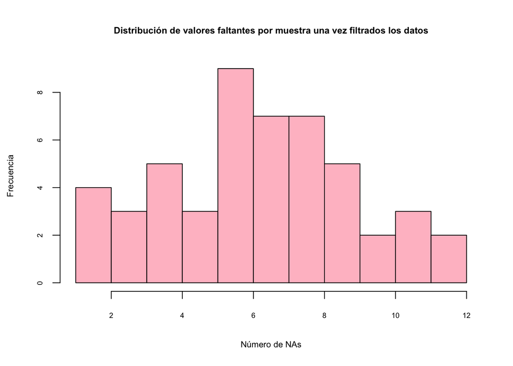

Histograma de la distribución de valores faltantes por muestra una vez filtrado los datos.

Finalmente, se realiza la normalización de los datos mediante la transformación logarítmica indicada en el apartado 2.2 para estabilidar la varianza y un autoescalado para que cada metabolito contribuya por igual en el modelo. Como se puede observar en la Figura 2, los datos originales tras la imputación son muy asimétricos, pero la transformación logarítmica hace que la varianza sea más estable. Por último, gracias al autoescalado todos los metabolitos se encuentran en una escala común permitiendo de esa manera que el análisis estadistico sea equitativo.

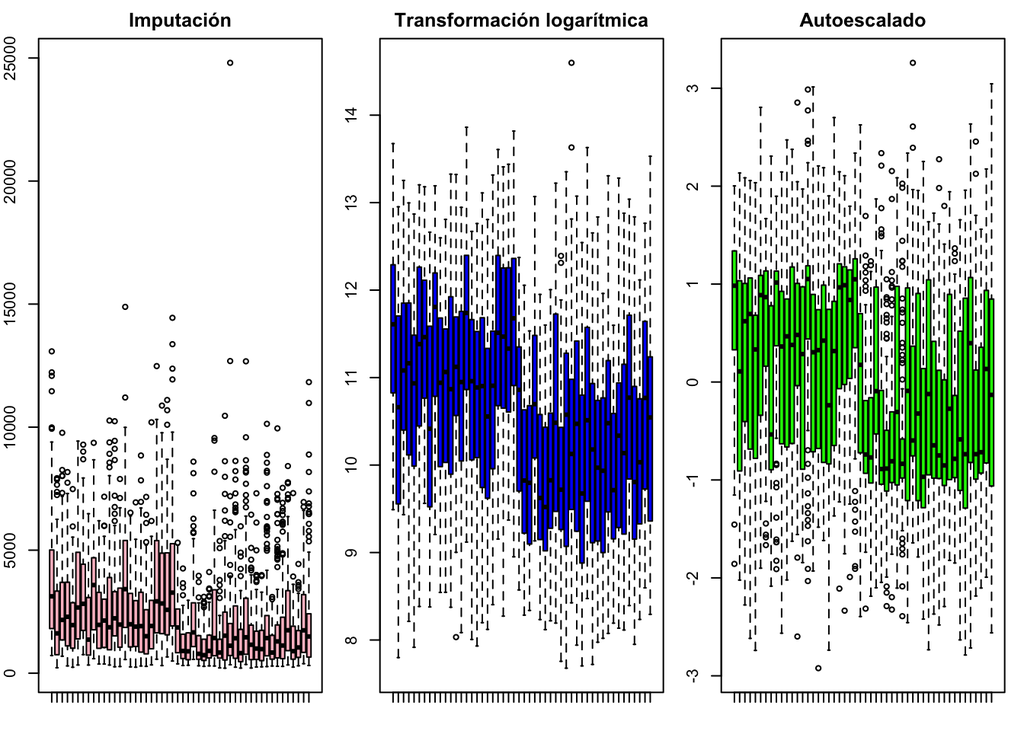

Comparación de la distribución de los datos tras la imputación KNN, la transformación logarítmica y el autoescalado.

### 3.2. Análisis mediante PCA

Una vez realizado el preprocesamiento de los datos, se ha realizado el análisis de componentes principales. En primer lugar, se ha generado un gráfico de sedimentación para determinar la variabilidad explicada del modelo. Como se observa en la Figura 3, la primera componente principal (PC1) tiene una varianza del 30.7% mientras que la segunda componente principal (PC2) tiene una varianza del 21.3%, siendo ambas las que más información contienen. Como a partir de PC2 la información se va estabilizando significativamente, se van a utilizar PC1 y PC2 para la interpretación biológica.

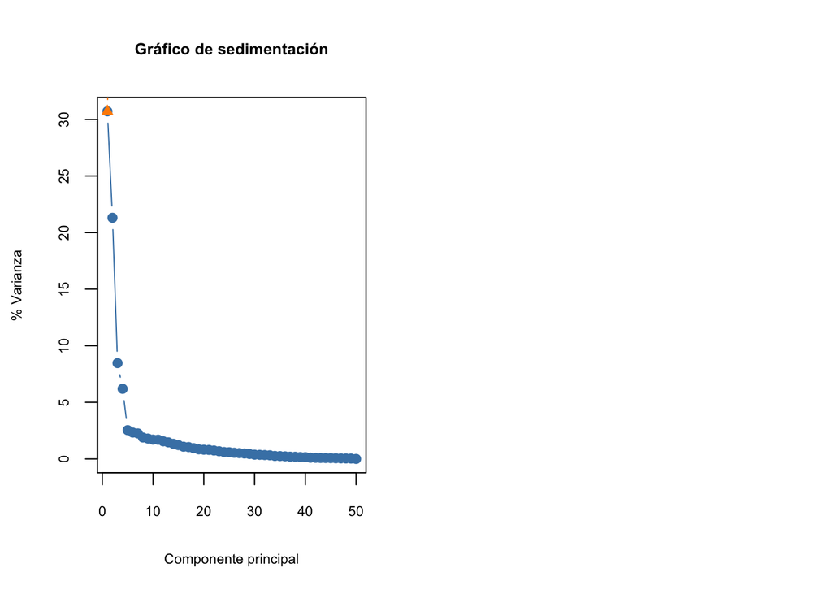

Gráfico de sedimentación.

En la Figura 4, se puede observar la proyección de muestras sobre PC1 y PC2. En ella, se ve que hay un separación entre las muestras del grupo “Case” y las del grupo “Control” a lo largo del eje de la PC1. De igual modo, las muestras de cada grupo estan agrupadas dentro del elipse de confianza y no hay casi ningun outlier.

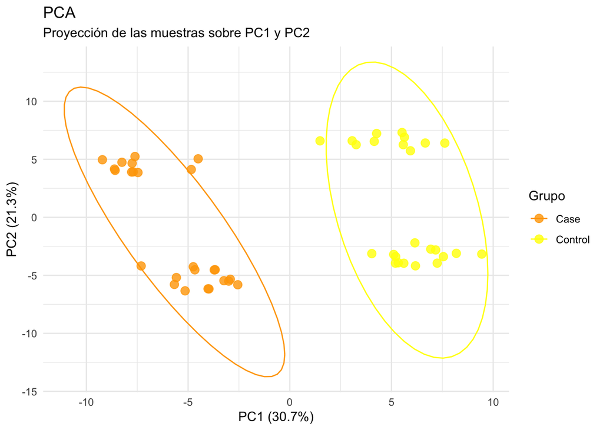

Gráfico de dispersión de PC1 y PC2

Finalmente, el análisis de carga que nos permite identificar los metabolitos que actuan en la separación que se ha observado anteriormente, nos da los siguientes resultados:

```
## Metabolitos con mayor carga positiva en PC1:
```

```
##       M112       M102       M098       M072       M106
## 0.04684566 0.03849180 0.03124863 0.02627523 0.01925311
```

```
##
## Metabolitos con mayor carga negativa en PC1:
```

```
##       M034       M038       M025       M022       M046
## -0.1601558 -0.1605055 -0.1606547 -0.1606890 -0.1608478
```

### 3.3 Comparación con t-SNE.

Para verificar los resultados del apartado anterior, se ha aplicado el algoritmo t-SNE. En la Figura 5, se puede observar que hay separación entre el grupo “Case” y el grupo “Control” como ocurre en el analisis mediante PCA. Además, que tanto el grupo enfermo como el sano se divide en dos islas independientes, indicando que hay variables secundarias que estan influyendo en los resultados.

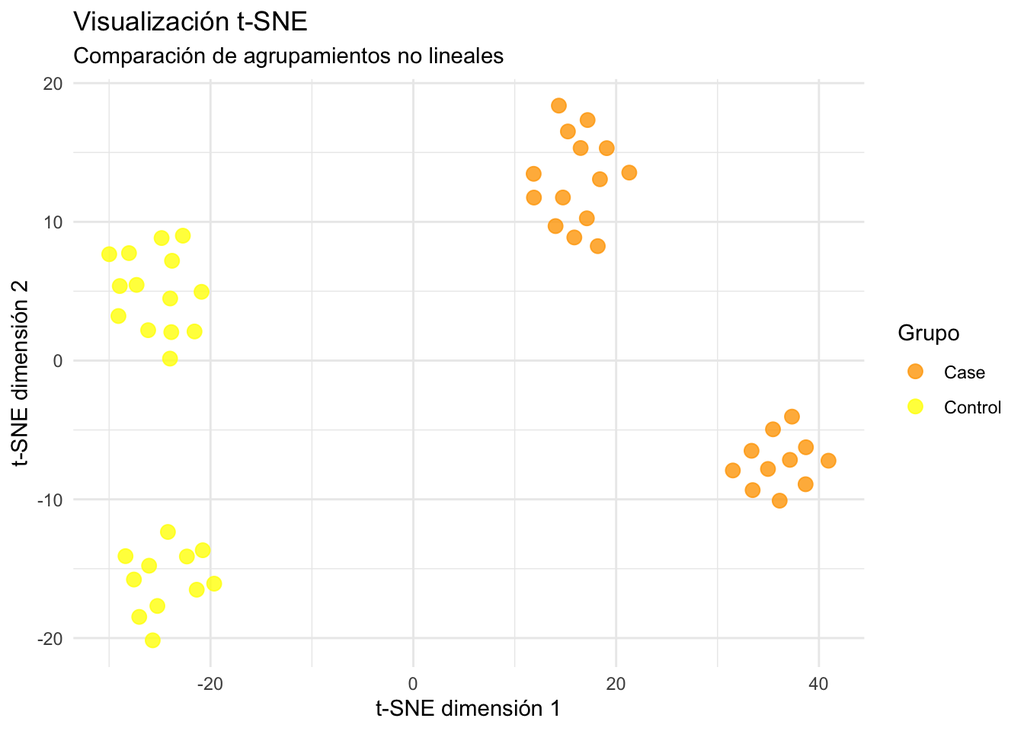

Visualización t-SNE

## 4. Discusión.

El análisis realizado en este estudio confirma que los datos utilizados tienen una estructura clara, ya que permiten distinguir perfectamente quién está sano y quién no lo está.

A través del PCA, podemos observar que el factor que influye en la variabilidad es la enfermedad (“Case”), ya que es el factor que separa a los pacientes de los controles. Sin embargo, el ánalisis mediante t-SNE nos da una vision complementaria, indicando que hay variables secundarias como la edad o el sexo que influyen en el metabolismo de las personas dando lugar a subgrupos en una misma condición clínica. Por tanto, ademas del factor enfermedad, hay otras caracteristicas que influyen en el nivel de los metabolitos, pero no podemos confirmarlas con total seguridad porque no se han analizado otras variables.

Finalmente, es necesario añadir que en este estudio hay varias limitaciones debido a que es unicamente un análisis exploratorio. Para investigaciones futuras, sería interesante investigar cuales son los otros factores que influyen en el metabolismo de las personas, así como realizar un análisis de rutas biológicas para entender el origen de estas diferencias.

## 5. Apéndice con el código utilizado.

```r
# Instalamos BiocManager e impute
if (!requireNamespace("BiocManager", quietly = TRUE)) {
    install.packages("BiocManager")}
if (!requireNamespace("SummarizedExperiment", quietly = TRUE)) {
    BiocManager::install("SummarizedExperiment")}
if (!requireNamespace("impute", quietly = TRUE)) {
    BiocManager::install("impute")}
if (!requireNamespace("Rtsne", quietly = TRUE)) install.packages("Rtsne")

# Cargamos los paquetes necesarios
library(SummarizedExperiment)
library(impute)
library(ggplot2)
library(Rtsne)
# Cargamos los datos cvs
datos_assay <- as.matrix(read.csv("assay.csv", row.names = 1))
sample_metadata <- read.csv("sample_metadata.csv", row.names = 1)
feature_metadata <- read.csv("feature_metadata.csv", row.names = 1)
# Para construir el contenedor primero tenemos que verificar que las columnas
# de la matriz coinciden con las filas de los metadatos
stopifnot(all(colnames(datos_assay)==rownames(sample_metadata)))
# Creamos el contenedor
se<- SummarizedExperiment(
  assays = list(counts=datos_assay),
  colData = sample_metadata,
  rowData = feature_metadata
)
# Ahora realizamos el sorteo aleatorio
# Primero especificamos la semilla
set.seed(2603)
# Despues identificamos los niveles de cada grupo
niv_grupo <- unique(se$group)
selec_indices <- c()
for (grupo in niv_grupo){
  posicion <- which(se$group==grupo) #Para coger las posiciones de las muestras
  # que pertenecen al grupo
  selec <- sample(posicion,25) #Seleccionamos las 25 muestras al azar de las
  # posiciones
  selec_indices <- c(selec_indices, selec) # Acumulamos los indices
}
# Por ultimo creamos un dataset con las 50 muestras que se han seleccionado
se_final <- se[,selec_indices]
print(colnames(se_final))
# Identificar y filtrar las variables mediante la regla del 80%
# Priero calculamos el número de NA por fila
val_faltantes <- rowSums(is.na(assay(se_final)))
# Proporcion de valores faltantes
proporc_val_faltantes <- val_faltantes/ncol(se_final)
# Vemos que metabolitos cumplen con la regla
metabolitos_final <- proporc_val_faltantes<=0.20
num_eliminados <- sum(!metabolitos_final)
# Filtramos
se_filtrado <- se_final[metabolitos_final,]
matriz_datos <- assay(se_filtrado)
# Para realizar la imputación con el algoritmo kNN, usamos k=5
resultados_knn <- impute.knn(as.matrix(matriz_datos), k=5)
matriz_datos_knn <- resultados_knn$data
# Transformamos los datos mediante la transformación logarítmica
transf_log <- log2(matriz_datos_knn+1)
# Austoescalado de los datos una vez transformados
matriz_final <- t(scale(t(transf_log)))
# Comprobación de dimensiones
cat("Resultados del filtrado:\n")
cat("- Metabolitos:", nrow(se_final), "\n")
cat("- Metabolitos eliminados ( > 20% NAs):", num_eliminados, "\n")
cat("- Metabolitos restantes:", nrow(se_filtrado), "\n")

# Comprobamos NAs por muestra
na_por_muestra <- colSums(is.na(matriz_datos))
hist(na_por_muestra,
     breaks = 10,
     col = "pink",
     main = "Distribución de valores faltantes por muestra una vez filtrados los datos",
     xlab = "Número de NAs",
     ylab = "Frecuencia", cex.main = 0.75, cex.lab=0.7, cex.axis=0.6)
# Verificamos si quedan valores faltantes en el dataset
cat("Valores faltantes:",any(is.na(matriz_datos)))
# Visualición comparativa tras la imputaión, la transformación logarítmica y el
# autoescalado
par(mfrow=c(1,3), mar=c(2, 2, 2, 1))
boxplot(matriz_datos_knn, main="Imputación", col="pink", names=FALSE)
boxplot(transf_log, main="Transformación logarítmica", col="blue", names=FALSE)
boxplot(matriz_final, main="Autoescalado", col="green", names=FALSE)
# Realizamos el PCA usando la matriz final
pca <- prcomp(t(matriz_final), scale. = FALSE)
# Calculamos la varianza
varianza <- (pca$sdev^2)/sum(pca$sdev^2)*100
varianza_acumulada <- cumsum(varianza)
par(mfrow=c(1,2))
# Creamos el grafico de sedimentacion
plot(varianza, type="b", pch=19, col="steelblue", main="Gráfico de sedimentación", xlab="Componente principal", ylab="% Varianza", cex.main = 0.8, cex.lab=0.7, cex.axis=0.7)
lines(varianza_acumulada, type="b", pch=17, col="darkorange")


# Creamos un dataframe para poder realizar el gráfico
pca_result <- data.frame(PC1=pca$x[,1], PC2=pca$x[,2], Grupo=se_filtrado$group)
# Creamos el gráfico de dispersion
ggplot(pca_result, aes(x=PC1, y=PC2, color=Grupo))+
  geom_point(size=3, alpha=0.8)+
  stat_ellipse(level = 0.95) + # Elipses de confianza al 95%
  scale_color_manual(values = c("Case" = "orange", "Control" = "yellow")) +
  labs(title = "PCA",
       subtitle = "Proyección de las muestras sobre PC1 y PC2",
       x = paste0("PC1 (", round(varianza[1], 1), "%)"),
       y = paste0("PC2 (", round(varianza[2], 1), "%)")) +
  theme_minimal()

# Extraenos las cargas del PC1
pc1_cargas <- pca$rotation[,1]
# Ordenamos de mayor a menor para ver los exremos
cargas_orden <- sort(pc1_cargas, decreasing = TRUE)
# Mostramos los 5 metabolitos del control
cat("Metabolitos con mayor carga positiva en PC1:\n")
head(cargas_orden, 5)
# Mostramos los 5 metabolitos del case
cat("\nMetabolitos con mayor carga negativa en PC1:\n")
tail(cargas_orden, 5)
set.seed(2603)
# Realizamos el t-SNE
tSNE<- Rtsne(t(matriz_final), perplexity=10, check_duplicates=FALSE)
# Creamos un dataset con el resultado
tSNE_resultados <- data.frame(Dim1=tSNE$Y[,1], Dim2=tSNE$Y[,2], Grupo=se_filtrado$group)
# Gráfico de dispersion de t-SNE
ggplot(tSNE_resultados, aes(x = Dim1, y = Dim2, color = Grupo)) +
  geom_point(size = 3, alpha = 0.8) +
  scale_color_manual(values = c("Case" = "orange", "Control" = "yellow")) +
  labs(title = "Visualización t-SNE",
       subtitle = "Comparación de agrupamientos no lineales",
       x = "t-SNE dimensión 1",
       y = "t-SNE dimensión 2") +
  theme_minimal()
```

## 6. Referencias.

Awan, Abid Ali. 2024. “Introducción a t-SNE: T-Distributed Stochastic Neighbor Embedding.” DataCamp. https://www.datacamp.com/es/tutorial/introduction-t-sne.

Berg, Robert A. van den, Huub C. J. Hoefsloot, Johan A. Westerhuis, Age K. Smilde, and Mariët J. van der Werf. 2006. “Centering, Scaling, and Transformations: Improving the Biological Information Content of Metabolomics Data.” *BMC Genomics* 7 (1): 142. https://doi.org/10.1186/1471-2164-7-142.

Di Guida, Riccardo, Jeroen Engel, J. William Allwood, et al. 2016. “Non-Targeted UHPLC-MS Metabolomic Data Processing Methods: A Comparative Investigation of Normalisation, Missing Value Imputation, Transformation and Scaling.” *Metabolomics* 12 (5): 93. https://doi.org/10.1007/s11306-016-1030-9.

Huber, Wolfgang, Vincent J. Carey, Robert Gentleman, Simon Anders, Marc Carlson, Benilton S. Carvalho, Hector Corrada Bravo, et al. 2015. “Orchestrating High-Throughput Genomic Analysis with Bioconductor.” *Nature Methods* 12 (2): 115–21. https://doi.org/10.1038/nmeth.3252.

National Cancer Institute. s.f. “Diccionario de Cáncer Del NCI: Metabolómica.” https://www.cancer.gov/espanol/buscar/resultados?swKeyword=metabol%C3%B3mica.

Van der Maaten, Laurens, and Geoffrey Hinton. 2008. “Visualizing Data Using t-SNE.” *Journal of Machine Learning Research* 9 (11): 2579–2605. https://www.jmlr.org/papers/volume9/vandermaaten08a/vandermaaten08a.pdf.

Wei, Ran, Jing Wang, Mingming Su, Erica Jia, Shilin Chen, Tianlu Chen, and Yan Ni. 2018. “Missing Value Imputation Approach for Mass Spectrometry-Based Metabolomics Data.” *Scientific Reports* 8 (1): 663. https://doi.org/10.1038/s41598-017-19120-0.

Wishart, David S. 2016. “Emerging Applications of Metabolomics in Drug Discovery and Precision Medicine.” *Nature Reviews Drug Discovery* 15 (7): 473–84. https://doi.org/10.1038/nrd.2016.32.

Worley, Bradley, and Robert Powers. 2013. “Multivariate Analysis in Metabolomics.” *Current Metabolomics* 1 (1): 92–107. https://doi.org/10.2174/2213235X11301010092.

# Ejercicio 2. Revisión de un artículo

## 1. Identificar y referenciar correctamente el artículo seleccionado.

Klein AM, Mazutis L, Akartuna I, Tallapragada N, Veres A, Li V, Peshkin L, Weitz DA, Kirschner MW. Droplet barcoding for single-cell transcriptomics applied to embryonic stem cells. Cell. 2015 May 21;161(5):1187-1201. doi: 10.1016/j.cell.2015.04.044. PMID: 26000487; PMCID: PMC4441768.

## 2. Describir brevemente el tipo de datos analizados y la pregunta general del estudio.

Este estudio analiza datos ómicos de secuenciación de ARN de célula única (scRNA-seq) obtenidos a partir de células madre embrionarias del ratón y células en proceso de diferenciación, mediante una técnica de microfluidez de gotas. El objetivo es entender si existe heterogeneidad dentro de las células madre embrionarias del ratón y si se pueden identificar subpoblaciones celulares.

## 3. Explicar por qué creéis que los autores aplican un método de reducción de dimensión en ese contexto.

Los autores aplican métodos de reducción debido a que los datos tienen muchas variables, es decir, alta dimensionalidad y son complejos, debido a que la célula está descrita por miles de genes. Estos métodos son importantes para poder manejar la información con menos datos y así minimizar el ruido estadístico y poner en evidencia los patrones biológicos más relevantes que están ocultos. Para ello, combinan el análisis de componentes principales (PCA) con t-SNE (t-distributed Stochastic Neighbor Embedding).

## 4. Describir cómo lo aplican en la práctica.

Utilizan el PCA para reducir la alta dimensionalidad de los datos, ya que es una herramienta importante para visualizar poblaciones celulares utilizando dos o tres ejes principales de expresión génica. Este análisis les permite seleccionar las componentes más significativas y eliminar dimensiones que solo tienen ruido. Sin embargo, como el PCA no es suficiente, se usa el t-SNE para reducir más la dimensionalidad. Por lo que, una vez extraída la información más relevante con el PCA, se usa el t-SNE para generar un mapa visual de células más claro. Este mapa revela un eje que va desde la pluripotencia hasta la diferenciación, mostrando subpoblaciones marginales en diferentes puntos del eje de diferenciación.

## 5. Comentar cómo interpretan los autores los resultados obtenidos.

Los autores interpretan que el movimiento de las células en el PCA/t-SNE refleja el estado de desarrollo de cada célula. Consiguen identificar una población de endodermo primitivo y una población de linaje de epiblasto. Además, observan que sin el factor de inhibición de leucemia (LIF), las células siguen trayectorias irregulares en el tiempo como se pueden visualizar en los mapas.

## 6. Valorar críticamente si el uso del método os parece adecuado, útil y bien integrado en el estudio.

El uso de estos métodos en este estudio es adecuado y realmente útil, ya que cumple una función clave al reducir el ruido y simplificar los datos complejos de interés en mapas visuales claros. Hay que añadir que sin el uso de estos métodos sería casi imposible analizar y visualizar todos los datos a la vez.

Gracias a esto, se pueden interpretar mejor los resultados, identificar subpoblaciones celulares y entender la trayectoria de la diferenciación. Sin embargo, es importante señalar que estos métodos también pueden dar lugar a limitaciones y a perdida de información relevante.